# Assignment n.5

GLM: the logistic regression model

2025-03-27

### **The *Auto* dataset**

The `ISLR2` library contains the `Auto` data set. Create a new data.frame `Auto.new` where:

1. the variable `mpg` is replaced by the variable `mpg01` that takes value 1 for the `mpg` values is greater than the median `mpg` and 0 otherwise,
2. the variable `name` is removed,
3. the variable origin is defined as a factor with levels “American”, “European” and “Japanese”.

Finally, attach the new data frame `Auto.new`.

```r
# load the data
library(ISLR2)
data(Auto)

# check the position of the variables
names(Auto)
```

```
## [1] "mpg"          "cylinders"    "displacement" "horsepower"   "weight"
## [6] "acceleration" "year"         "origin"       "name"
```

```r
# create Auto new where you remove the variables mpg and name
Auto.new <- Auto[, -c(1, 9)]

# create the binary response mpg01 and check the result
Auto.new$mpg01 <- as.numeric(Auto$mpg>median(Auto$mpg))
table(Auto.new$mpg01)
```

```
##
##   0   1
## 196 196
```

```r
# define origin as a factor
Auto.new$origin <- factor(Auto$origin, levels=1:3, labels =c("American", "European", "Japanese"))

# check the result and attach the new data.frame
names(Auto.new)
```

```
## [1] "cylinders"    "displacement" "horsepower"   "weight"       "acceleration"
## [6] "year"         "origin"       "mpg01"
```

```r
attach(Auto.new)
```

### **We first consider the single predictor `horsepower`**

##### 1. **Carry out a logistic regression analysis with `mpg01` as response and `horsepower` as predictor, along the following steps:**

1. **Use a boxplot to display the relationship between the two variables,**
2. **fit the logistic regression model and visualize the result,**
3. **use the function `anova()` to carry out a deviance difference test for the hypothesis that the coefficient of `horsepower` is equal to zero,**
4. **produce a plot with the data and the fitted logistic regression curve.**

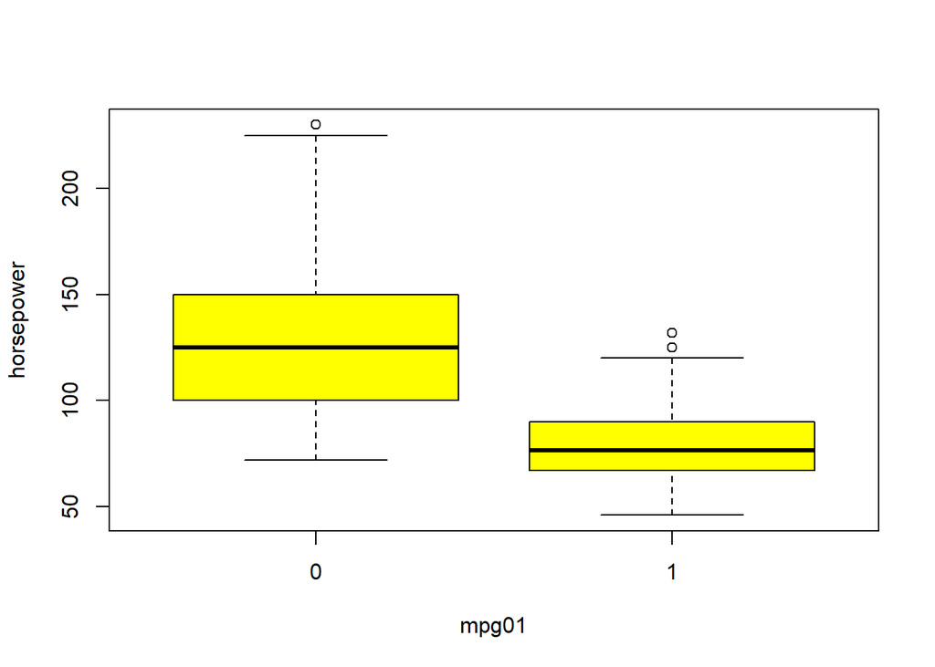

```r
# boxplot
boxplot(horsepower~mpg01, col="yellow")
```

```r
# fit the logistic regression model
glmfit <- glm(mpg01~horsepower, data=Auto.new, family=binomial)
summary(glmfit)
```

```
##
## Call:
## glm(formula = mpg01 ~ horsepower, family = binomial, data = Auto.new)
##
## Coefficients:
##             Estimate Std. Error z value Pr(>|z|)
## (Intercept)  9.29885    1.00692   9.235   <2e-16 ***
## horsepower  -0.09675    0.01080  -8.958   <2e-16 ***
## ---
## Signif. codes:  0 '***' 0.001 '**' 0.01 '*' 0.05 '.' 0.1 ' ' 1
##
## (Dispersion parameter for binomial family taken to be 1)
##
##     Null deviance: 543.43  on 391  degrees of freedom
## Residual deviance: 276.51  on 390  degrees of freedom
## AIC: 280.51
##
## Number of Fisher Scoring iterations: 6
```

```r
# deviance difference test
glmfit.red <- glm(mpg01~+1, data=Auto.new, family=binomial)
anova(glmfit.red, glmfit, test="Chisq")
```

```
## Analysis of Deviance Table
##
## Model 1: mpg01 ~ +1
## Model 2: mpg01 ~ horsepower
##   Resid. Df Resid. Dev Df Deviance  Pr(>Chi)
## 1       391     543.43
## 2       390     276.51  1   266.92 < 2.2e-16 ***
## ---
## Signif. codes:  0 '***' 0.001 '**' 0.01 '*' 0.05 '.' 0.1 ' ' 1
```

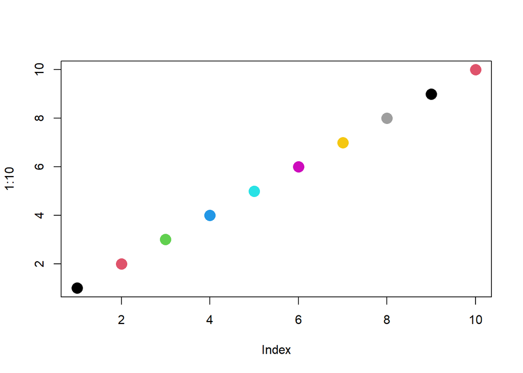

```r
# Firstly, note that:
# a) the main colors are associated with numbers
# b) a different color can be specified for every data point
# c) 1=black and 2=red
#
# This is shown in the following plot,
#
plot(1:10, pch=16, col=1:10, cex=2)
```

```r
# in this way we obtain a sequence of 1's and 2's to
# be used as "col" argument in the plot
#
(mpg01+1)[10:30]
```

```
##  [1] 1 1 1 1 1 2 1 1 1 2 2 2 2 2 2 1 1 1 1 1 2
```

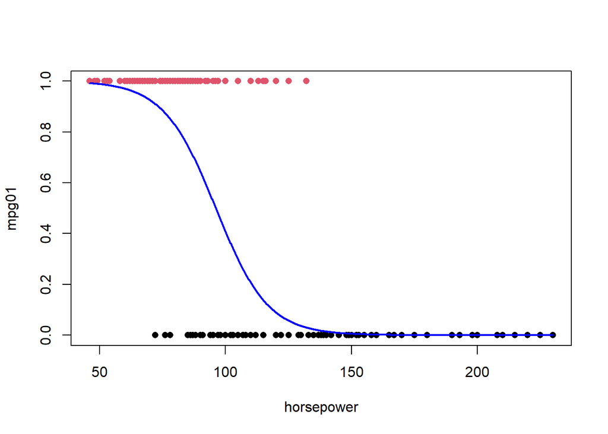

```r
plot(horsepower, mpg01, col=mpg01+1, pch=16)

# plot the data points together with the logistic regression curve
#
horsepower.seq <- seq(min(horsepower), max(horsepower), length=1000)
horsepower.new <- data.frame(horsepower=horsepower.seq)
pi.seq <- predict(glmfit, newdata = horsepower.new, type="response")
lines(horsepower.seq, pi.seq, col="blue", lwd=2)
```

### **We now consider the single predictor `year`**

##### 1. **Carry out a logistic regression analysis with `mpg01` as response and `year` as predictor, along the same steps of the previous point.**

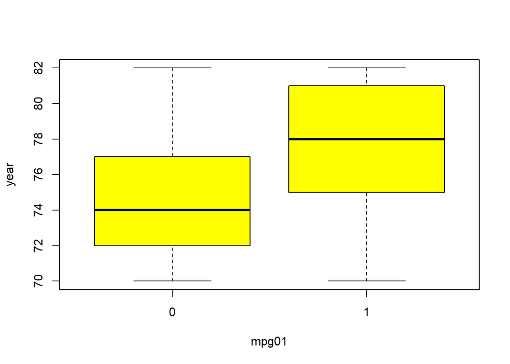

```r
boxplot(year~mpg01, col="yellow")
```

```r
glmfit <- glm(mpg01~year, data=Auto.new, family=binomial)
summary(glmfit)
```

```
##
## Call:
## glm(formula = mpg01 ~ year, family = binomial, data = Auto.new)
##
## Coefficients:
##              Estimate Std. Error z value Pr(>|z|)
## (Intercept) -20.20537    2.53754  -7.963 1.68e-15 ***
## year          0.26595    0.03337   7.969 1.59e-15 ***
## ---
## Signif. codes:  0 '***' 0.001 '**' 0.01 '*' 0.05 '.' 0.1 ' ' 1
##
## (Dispersion parameter for binomial family taken to be 1)
##
##     Null deviance: 543.43  on 391  degrees of freedom
## Residual deviance: 466.32  on 390  degrees of freedom
## AIC: 470.32
##
## Number of Fisher Scoring iterations: 4
```

```r
glmfit.red  <- glm(mpg01~+1, data=Auto.new, family=binomial)
anova(glmfit.red, glmfit)
```

```
## Analysis of Deviance Table
##
## Model 1: mpg01 ~ +1
## Model 2: mpg01 ~ year
##   Resid. Df Resid. Dev Df Deviance  Pr(>Chi)
## 1       391     543.43
## 2       390     466.32  1   77.108 < 2.2e-16 ***
## ---
## Signif. codes:  0 '***' 0.001 '**' 0.01 '*' 0.05 '.' 0.1 ' ' 1
```

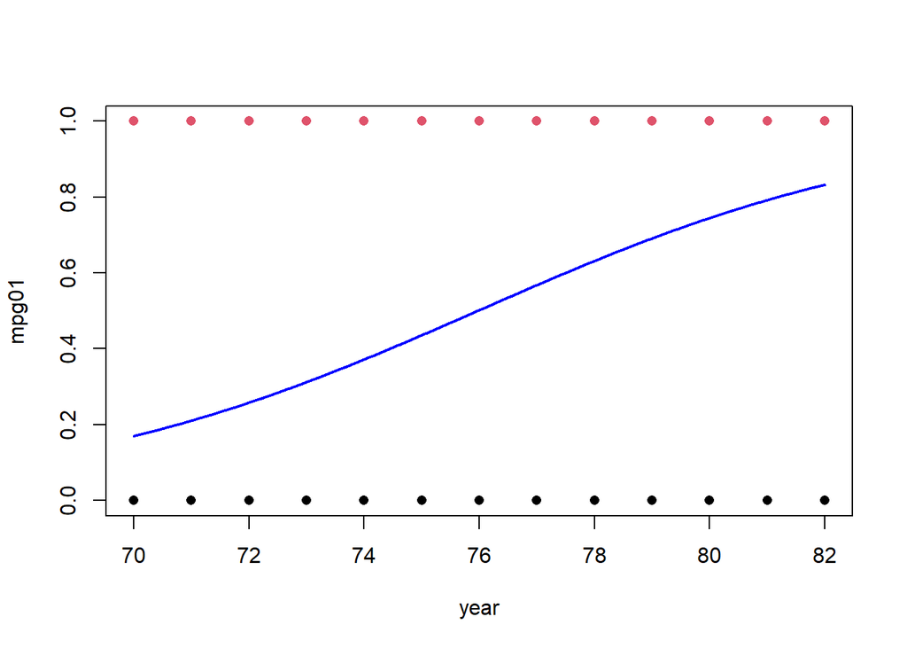

```r
plot(year, mpg01, col=mpg01+1, pch=16)

year.seq <- seq(min(year), max(year), length=1000)
year.new <- data.frame(year=year.seq)
pi.seq <- predict(glmfit, newdata = year.new, type="response")
lines(year.seq, pi.seq, col="blue", lwd=2)
```

### **We now include all the predictors in the model**

##### 1. **Fit the model and, iteratively, remove the variables with variance inflation factor greater than 10 (recall that you need to load the package `car`)**

```r
library(car)
glmfit.full <- glm(mpg01~., data=Auto.new, family=binomial)
summary(glmfit.full)
```

```
##
## Call:
## glm(formula = mpg01 ~ ., family = binomial, data = Auto.new)
##
## Coefficients:
##                  Estimate Std. Error z value Pr(>|z|)
## (Intercept)    -19.450793   5.956353  -3.266  0.00109 **
## cylinders       -0.264169   0.439645  -0.601  0.54793
## displacement     0.015568   0.013658   1.140  0.25434
## horsepower      -0.043081   0.024621  -1.750  0.08017 .
## weight          -0.005762   0.001376  -4.187 2.83e-05 ***
## acceleration     0.012939   0.142921   0.091  0.92786
## year             0.495635   0.086155   5.753 8.78e-09 ***
## originEuropean   1.971277   0.785573   2.509  0.01210 *
## originJapanese   1.102741   0.713768   1.545  0.12236
## ---
## Signif. codes:  0 '***' 0.001 '**' 0.01 '*' 0.05 '.' 0.1 ' ' 1
##
## (Dispersion parameter for binomial family taken to be 1)
##
##     Null deviance: 543.43  on 391  degrees of freedom
## Residual deviance: 152.30  on 383  degrees of freedom
## AIC: 170.3
##
## Number of Fisher Scoring iterations: 8
```

```r
vif(glmfit.full)
```

```
##                   GVIF Df GVIF^(1/(2*Df))
## cylinders     5.410047  1        2.325951
## displacement 11.604209  1        3.406495
## horsepower    2.694488  1        1.641490
## weight        6.602953  1        2.569621
## acceleration  2.522107  1        1.588114
## year          2.163868  1        1.471009
## origin        3.078351  2        1.324584
```

```r
# remove displacement

glmfit.r1 <- update(glmfit.full, ~.-displacement)
summary(glmfit.r1)
```

```
##
## Call:
## glm(formula = mpg01 ~ cylinders + horsepower + weight + acceleration +
##     year + origin, family = binomial, data = Auto.new)
##
## Coefficients:
##                  Estimate Std. Error z value Pr(>|z|)
## (Intercept)    -1.844e+01  5.859e+00  -3.148  0.00165 **
## cylinders       1.007e-01  2.983e-01   0.337  0.73577
## horsepower     -4.422e-02  2.455e-02  -1.801  0.07170 .
## weight         -4.790e-03  1.035e-03  -4.627  3.7e-06 ***
## acceleration    3.035e-04  1.419e-01   0.002  0.99829
## year            4.627e-01  7.794e-02   5.937  2.9e-09 ***
## originEuropean  1.430e+00  6.046e-01   2.365  0.01804 *
## originJapanese  6.693e-01  5.931e-01   1.128  0.25916
## ---
## Signif. codes:  0 '***' 0.001 '**' 0.01 '*' 0.05 '.' 0.1 ' ' 1
##
## (Dispersion parameter for binomial family taken to be 1)
##
##     Null deviance: 543.43  on 391  degrees of freedom
## Residual deviance: 153.61  on 384  degrees of freedom
## AIC: 169.61
##
## Number of Fisher Scoring iterations: 8
```

```r
vif(glmfit.r1)
```

```
##                  GVIF Df GVIF^(1/(2*Df))
## cylinders    2.410614  1        1.552615
## horsepower   2.640627  1        1.625001
## weight       3.687649  1        1.920325
## acceleration 2.505864  1        1.582992
## year         1.792847  1        1.338972
## origin       1.730265  2        1.146907
```

##### 2. **Perform a stepwise, backward elimination, selection of the variables. At every step compompute also the deviance difference test.**

```r
summary(glmfit.r1)
```

```
##
## Call:
## glm(formula = mpg01 ~ cylinders + horsepower + weight + acceleration +
##     year + origin, family = binomial, data = Auto.new)
##
## Coefficients:
##                  Estimate Std. Error z value Pr(>|z|)
## (Intercept)    -1.844e+01  5.859e+00  -3.148  0.00165 **
## cylinders       1.007e-01  2.983e-01   0.337  0.73577
## horsepower     -4.422e-02  2.455e-02  -1.801  0.07170 .
## weight         -4.790e-03  1.035e-03  -4.627  3.7e-06 ***
## acceleration    3.035e-04  1.419e-01   0.002  0.99829
## year            4.627e-01  7.794e-02   5.937  2.9e-09 ***
## originEuropean  1.430e+00  6.046e-01   2.365  0.01804 *
## originJapanese  6.693e-01  5.931e-01   1.128  0.25916
## ---
## Signif. codes:  0 '***' 0.001 '**' 0.01 '*' 0.05 '.' 0.1 ' ' 1
##
## (Dispersion parameter for binomial family taken to be 1)
##
##     Null deviance: 543.43  on 391  degrees of freedom
## Residual deviance: 153.61  on 384  degrees of freedom
## AIC: 169.61
##
## Number of Fisher Scoring iterations: 8
```

```r
# step 1
glmfit.r2 <- update(glmfit.r1, ~. -acceleration)
anova(glmfit.r2, glmfit.r1)
```

```
## Analysis of Deviance Table
##
## Model 1: mpg01 ~ cylinders + horsepower + weight + year + origin
## Model 2: mpg01 ~ cylinders + horsepower + weight + acceleration + year +
##     origin
##   Resid. Df Resid. Dev Df   Deviance Pr(>Chi)
## 1       385     153.61
## 2       384     153.61  1 4.5782e-06   0.9983
```

```r
summary(glmfit.r2)
```

```
##
## Call:
## glm(formula = mpg01 ~ cylinders + horsepower + weight + year +
##     origin, family = binomial, data = Auto.new)
##
## Coefficients:
##                  Estimate Std. Error z value Pr(>|z|)
## (Intercept)    -1.844e+01  4.950e+00  -3.725 0.000196 ***
## cylinders       1.006e-01  2.970e-01   0.339 0.734835
## horsepower     -4.426e-02  1.762e-02  -2.512 0.012020 *
## weight         -4.789e-03  9.206e-04  -5.203 1.97e-07 ***
## year            4.627e-01  7.775e-02   5.952 2.65e-09 ***
## originEuropean  1.430e+00  6.039e-01   2.368 0.017901 *
## originJapanese  6.693e-01  5.931e-01   1.128 0.259153
## ---
## Signif. codes:  0 '***' 0.001 '**' 0.01 '*' 0.05 '.' 0.1 ' ' 1
##
## (Dispersion parameter for binomial family taken to be 1)
##
##     Null deviance: 543.43  on 391  degrees of freedom
## Residual deviance: 153.61  on 385  degrees of freedom
## AIC: 167.61
##
## Number of Fisher Scoring iterations: 8
```

```r
# step 2
glmfit.r3 <- update(glmfit.r2, ~. -cylinders)
anova(glmfit.r3, glmfit.r2)
```

```
## Analysis of Deviance Table
##
## Model 1: mpg01 ~ horsepower + weight + year + origin
## Model 2: mpg01 ~ cylinders + horsepower + weight + year + origin
##   Resid. Df Resid. Dev Df Deviance Pr(>Chi)
## 1       386     153.73
## 2       385     153.61  1  0.11467   0.7349
```

```r
summary(glmfit.r3)
```

```
##
## Call:
## glm(formula = mpg01 ~ horsepower + weight + year + origin, family = binomial,
##     data = Auto.new)
##
## Coefficients:
##                  Estimate Std. Error z value Pr(>|z|)
## (Intercept)    -18.240055   4.912407  -3.713 0.000205 ***
## horsepower      -0.042209   0.016441  -2.567 0.010251 *
## weight          -0.004607   0.000734  -6.276 3.47e-10 ***
## year             0.457663   0.075997   6.022 1.72e-09 ***
## originEuropean   1.335225   0.529879   2.520 0.011740 *
## originJapanese   0.628677   0.580123   1.084 0.278500
## ---
## Signif. codes:  0 '***' 0.001 '**' 0.01 '*' 0.05 '.' 0.1 ' ' 1
##
## (Dispersion parameter for binomial family taken to be 1)
##
##     Null deviance: 543.43  on 391  degrees of freedom
## Residual deviance: 153.73  on 386  degrees of freedom
## AIC: 165.73
##
## Number of Fisher Scoring iterations: 8
```

```r
# step 3
glmfit.r4 <- update(glmfit.r3, ~. -origin)
anova(glmfit.r4, glmfit.r3)
```

```
## Analysis of Deviance Table
##
## Model 1: mpg01 ~ horsepower + weight + year
## Model 2: mpg01 ~ horsepower + weight + year + origin
##   Resid. Df Resid. Dev Df Deviance Pr(>Chi)
## 1       388     160.58
## 2       386     153.73  2   6.8528   0.0325 *
## ---
## Signif. codes:  0 '***' 0.001 '**' 0.01 '*' 0.05 '.' 0.1 ' ' 1
```

```r
# name the selected model "glmfit"
glmfit <- glmfit.r3
summary(glmfit)
```

```
##
## Call:
## glm(formula = mpg01 ~ horsepower + weight + year + origin, family = binomial,
##     data = Auto.new)
##
## Coefficients:
##                  Estimate Std. Error z value Pr(>|z|)
## (Intercept)    -18.240055   4.912407  -3.713 0.000205 ***
## horsepower      -0.042209   0.016441  -2.567 0.010251 *
## weight          -0.004607   0.000734  -6.276 3.47e-10 ***
## year             0.457663   0.075997   6.022 1.72e-09 ***
## originEuropean   1.335225   0.529879   2.520 0.011740 *
## originJapanese   0.628677   0.580123   1.084 0.278500
## ---
## Signif. codes:  0 '***' 0.001 '**' 0.01 '*' 0.05 '.' 0.1 ' ' 1
##
## (Dispersion parameter for binomial family taken to be 1)
##
##     Null deviance: 543.43  on 391  degrees of freedom
## Residual deviance: 153.73  on 386  degrees of freedom
## AIC: 165.73
##
## Number of Fisher Scoring iterations: 8
```

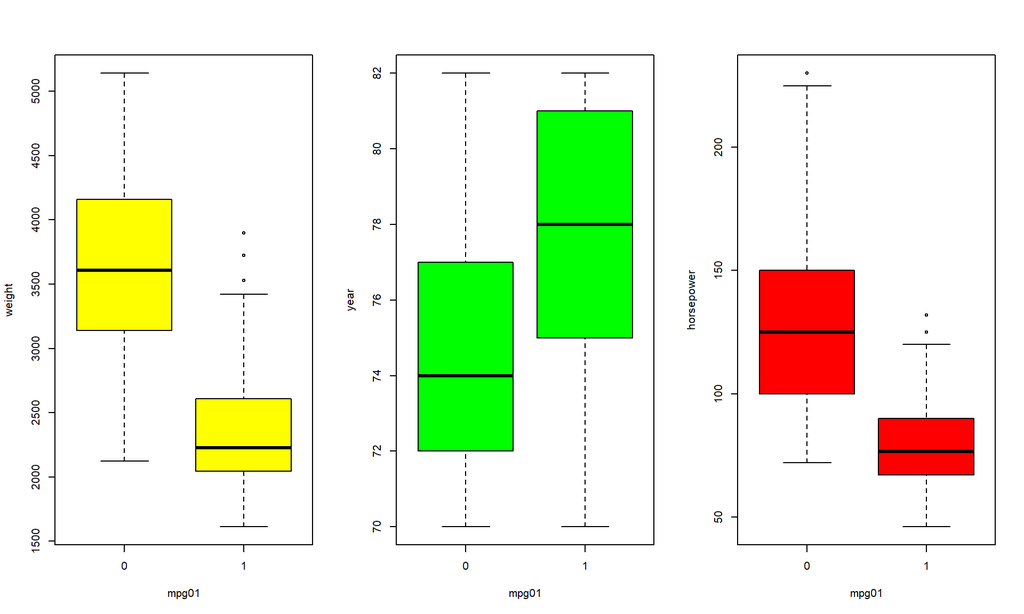

```r
# some plots to visualize the relationships between predictors
# and the response


# look at some boxplots
par(mfrow=c(1, 3))
boxplot(weight~mpg01, col="yellow")
boxplot(year~mpg01, col="green")
boxplot(horsepower~mpg01, col="red")
```

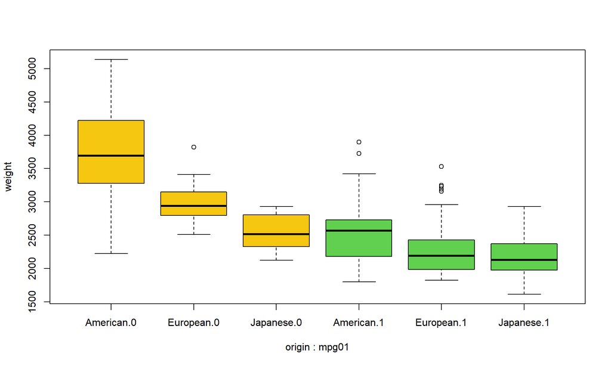

```r
par(mfrow=c(1,1))


boxplot(weight~origin+mpg01, col=c(7,7,7,3,3,3))
```

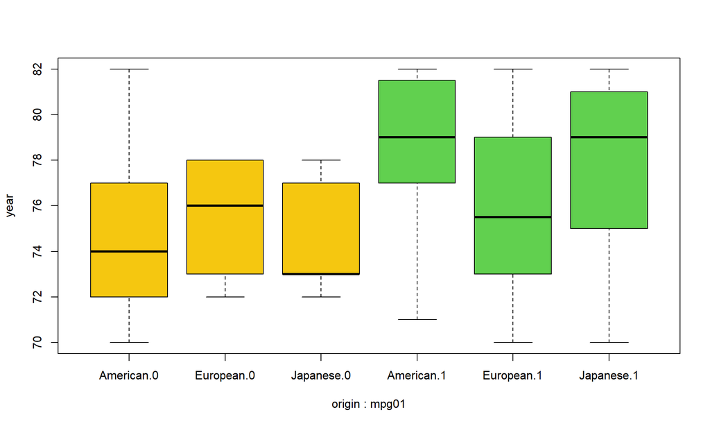

```r
boxplot(year~origin+mpg01, col=c(7,7,7,3,3,3))
```

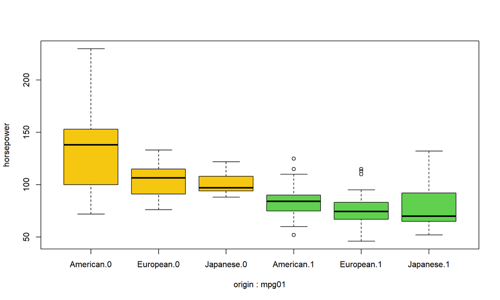

```r
boxplot(horsepower~origin+mpg01, col=c(7,7,7,3,3,3))
```

##### 3. **Use the selected model to classify the data points along the following points:**

1. **Apply the function `predict()` to obtain the estimated response probabilities,**
2. **assign value 1 to the units with probability greater than 0.5**
3. **obtain a confusion matrix and compute the overall misclassification error**

```r
# compute the estimated probabilities
pi.hat <- predict(glmfit, type="response")

# classify the units and check the result
mpg01.hat <- as.numeric(pi.hat>0.5)
mpg01.hat[10:30]
```

```
##  [1] 0 0 0 0 0 0 0 0 0 1 1 0 1 1 1 0 0 0 0 0 1
```

```r
# compute the confusion matrix
conf.matrix <- table(mpg01, mpg01.hat)
conf.matrix
```

```
##      mpg01.hat
## mpg01   0   1
##     0 174  22
##     1  10 186
```

```r
# compute the overall misclassification error
(conf.matrix[1,2]+conf.matrix[2,1])/sum(conf.matrix)
```

```
## [1] 0.08163265
```

##### 4. **Use the model with the single predictor `horsepower` to classify the data points and compute the misclassification error:**

```r
# fit the model
glmfit.h <- glm(mpg01~horsepower, data=Auto.new, family=binomial)

# classify the units
pi.hat <- predict(glmfit.h, type="response")
mpg01.hat <- as.numeric(pi.hat>0.5)

# obtain the confusion matrix
conf.matrix <- table(mpg01, mpg01.hat)
conf.matrix
```

```
##      mpg01.hat
## mpg01   0   1
##     0 157  39
##     1  21 175
```

```r
# calculate the overall misclassification error
(conf.matrix[1,2]+conf.matrix[2,1])/sum(conf.matrix)
```

```
## [1] 0.1530612
```

##### 5. **Use the model with the single predictor `year` to classify the data points and compute the misclassification error:**

```r
# fit the model
glmfit.y <- glm(mpg01~year, data=Auto.new, family=binomial)

# classify the units
pi.hat <- predict(glmfit.y, type="response")
mpg01.hat <- as.numeric(pi.hat>0.5)

# obtain the confusion matrix
conf.matrix <- table(mpg01, mpg01.hat)
conf.matrix
```

```
##      mpg01.hat
## mpg01   0   1
##     0 122  74
##     1  58 138
```

```r
# calculate the overall misclassification error
(conf.matrix[1,2]+conf.matrix[2,1])/sum(conf.matrix)
```

```
## [1] 0.3367347
```

### **The *SocialNetworkAds.csv* dataset**

The Dataset contains information about users on a Social Networking site. The response variable `Purchased` record whether a particular user, after clicking on an ad on the Social networking site, goes on to buy a particular product or not (1=“yes”, 0=“no”). The predictors are `Age` `EstimatedSalary` and `Gender`.

##### 1. **Load the dataset, fit a logistic regression model and show that the coefficient of `Gender` is not significantly different to zero**

```r
sndata <- read.csv("SocialNetworkAds.csv", head=TRUE)
attach(sndata)
names(sndata)
```

```
## [1] "UserID"          "Gender"          "Age"             "EstimatedSalary"
## [5] "Purchased"
```

```r
glmfit.full <- glm(Purchased~Age+EstimatedSalary+Gender, family=binomial)
summary(glmfit.full)
```

```
##
## Call:
## glm(formula = Purchased ~ Age + EstimatedSalary + Gender, family = binomial)
##
## Coefficients:
##                   Estimate Std. Error z value Pr(>|z|)
## (Intercept)     -1.278e+01  1.359e+00  -9.405  < 2e-16 ***
## Age              2.370e-01  2.638e-02   8.984  < 2e-16 ***
## EstimatedSalary  3.644e-05  5.473e-06   6.659 2.77e-11 ***
## GenderMale       3.338e-01  3.052e-01   1.094    0.274
## ---
## Signif. codes:  0 '***' 0.001 '**' 0.01 '*' 0.05 '.' 0.1 ' ' 1
##
## (Dispersion parameter for binomial family taken to be 1)
##
##     Null deviance: 521.57  on 399  degrees of freedom
## Residual deviance: 275.84  on 396  degrees of freedom
## AIC: 283.84
##
## Number of Fisher Scoring iterations: 6
```

```r
glmfit <- glm(Purchased~Age+EstimatedSalary, family=binomial)
summary(glmfit)
```

```
##
## Call:
## glm(formula = Purchased ~ Age + EstimatedSalary, family = binomial)
##
## Coefficients:
##                   Estimate Std. Error z value Pr(>|z|)
## (Intercept)     -1.243e+01  1.300e+00  -9.566  < 2e-16 ***
## Age              2.335e-01  2.591e-02   9.013  < 2e-16 ***
## EstimatedSalary  3.590e-05  5.429e-06   6.613 3.77e-11 ***
## ---
## Signif. codes:  0 '***' 0.001 '**' 0.01 '*' 0.05 '.' 0.1 ' ' 1
##
## (Dispersion parameter for binomial family taken to be 1)
##
##     Null deviance: 521.57  on 399  degrees of freedom
## Residual deviance: 277.05  on 397  degrees of freedom
## AIC: 283.05
##
## Number of Fisher Scoring iterations: 6
```

##### 2. **Use the selected model with predictors `Age` `EstimatedSalary` to classify the data points and compute the misclassification error**

```r
pi.hat <- predict(glmfit, type="response")
Purchased.hat <- as.numeric(pi.hat>0.5)

conf.matrix <- table(Purchased, Purchased.hat)
(conf.matrix[1,2]+conf.matrix[2,1])/sum(conf.matrix)
```

```
## [1] 0.155
```

##### 3. **Plot `Age` against `EstimatedSalary` using different colors for different values of the response (e.g. red=yes=1, black=no=0) and represent the classification boundary**

```r
plot(Age, EstimatedSalary, col=Purchased+1, pch=20)
legend("topleft", legend=c("no", "yes"), col=1:2,  pch=20)

beta.hat <- coefficients(glmfit)
beta.hat
```

```
##     (Intercept)             Age EstimatedSalary
##   -1.243399e+01    2.334894e-01    3.590094e-05
```

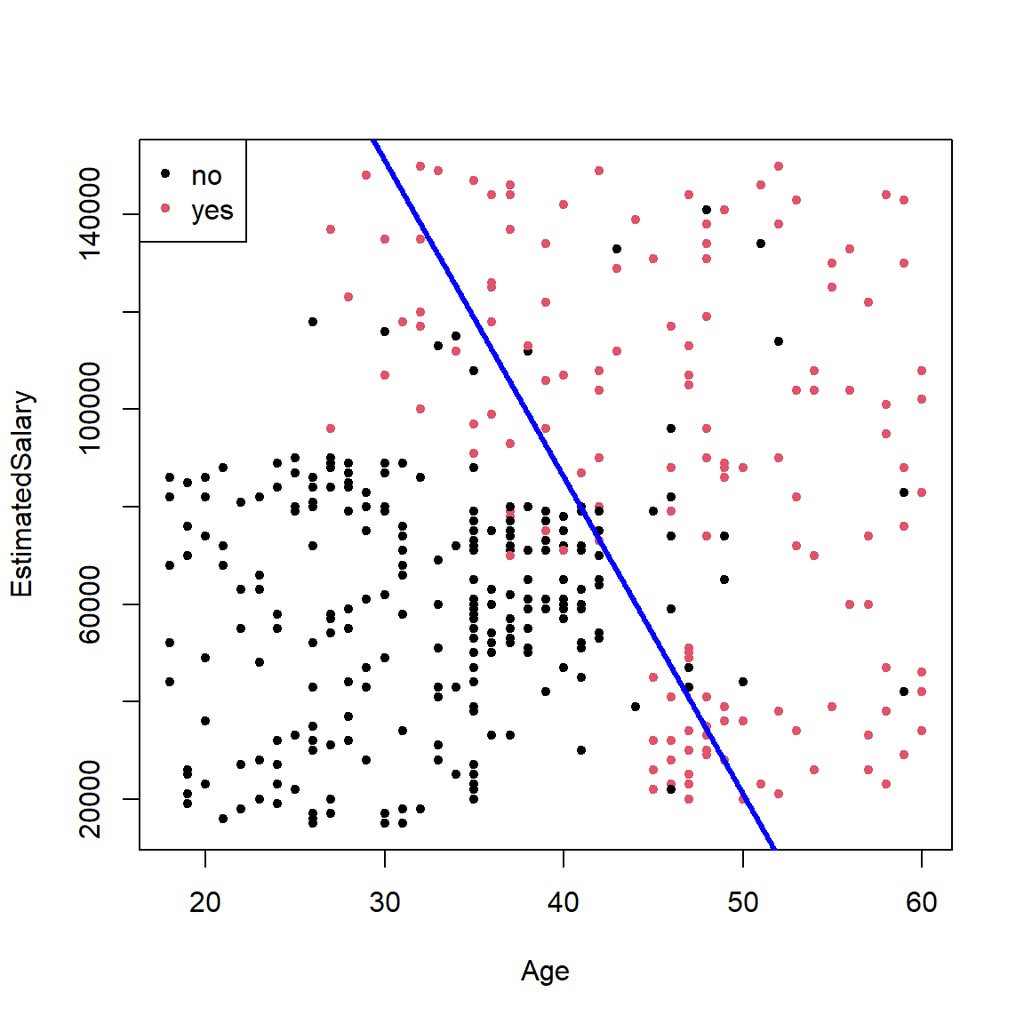

```r
beta0.hat <- beta.hat[1]
beta1.hat <- beta.hat[2]
beta2.hat <- beta.hat[3]

age.seq <- seq(min(Age), max(Age), length=1000)

# the classification boundary can be computed as (not required for the exam)
y <- -(beta0.hat+beta1.hat*age.seq)/beta2.hat

lines(age.seq, y, col="blue", lwd=3)
```

##### 4. **Fit the model including the interaction between `Age` and `EstimatedSalary`. Use it to classify the data points and compute the misclassification error**

```r
glmfit <- glm(Purchased~Age*EstimatedSalary, family=binomial)
summary(glmfit)
```

```
##
## Call:
## glm(formula = Purchased ~ Age * EstimatedSalary, family = binomial)
##
## Coefficients:
##                       Estimate Std. Error z value Pr(>|z|)
## (Intercept)         -3.611e+01  4.419e+00  -8.172 3.03e-16 ***
## Age                  7.750e-01  9.770e-02   7.933 2.14e-15 ***
## EstimatedSalary      3.004e-04  4.233e-05   7.098 1.27e-12 ***
## Age:EstimatedSalary -6.146e-06  9.214e-07  -6.670 2.55e-11 ***
## ---
## Signif. codes:  0 '***' 0.001 '**' 0.01 '*' 0.05 '.' 0.1 ' ' 1
##
## (Dispersion parameter for binomial family taken to be 1)
##
##     Null deviance: 521.57  on 399  degrees of freedom
## Residual deviance: 213.57  on 396  degrees of freedom
## AIC: 221.57
##
## Number of Fisher Scoring iterations: 7
```

```r
pi.hat <- predict(glmfit, type="response")
Purchased.hat <- as.numeric(pi.hat>0.5)

conf.matrix <- table(Purchased, Purchased.hat)
(conf.matrix[1,2]+conf.matrix[2,1])/sum(conf.matrix)
```

```
## [1] 0.1125
```

##### 5. **Add to the plot the classification boundary of the model of point 3**

```r
beta.hat <- coefficients(glmfit)
beta.hat
```

```
##         (Intercept)                 Age     EstimatedSalary Age:EstimatedSalary
##       -3.610987e+01        7.750209e-01        3.004275e-04       -6.145864e-06
```

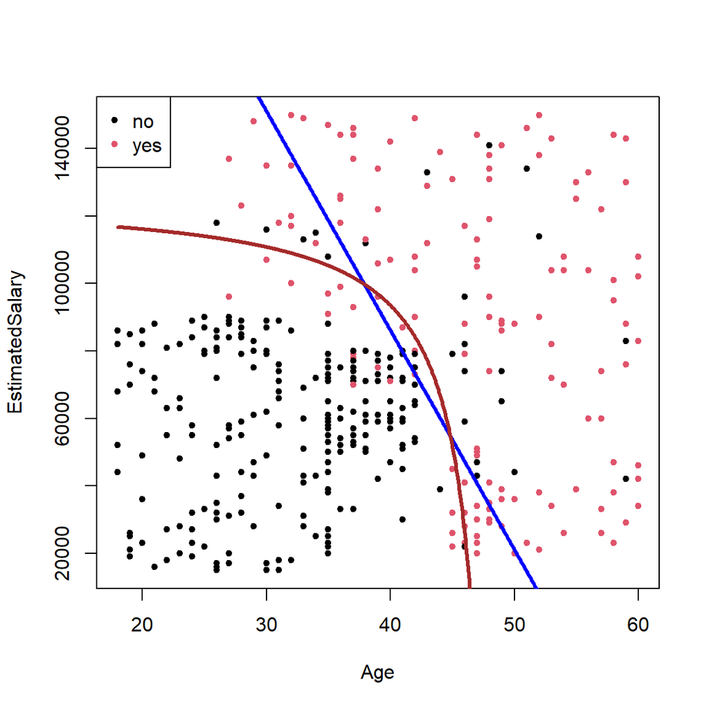

```r
beta0.hat <- beta.hat[1]
beta1.hat <- beta.hat[2]
beta2.hat <- beta.hat[3]
beta3.hat <- beta.hat[4]

# previous plot
plot(Age, EstimatedSalary, col=Purchased+1, pch=20)
legend("topleft", legend=c("no", "yes"), col=1:2,  pch=20)
lines(age.seq, y, col="blue", lwd=3)

# the classification boundary can be computed as (not required for the exam)
y <- -(beta0.hat+beta1.hat*age.seq)/abs(beta2.hat+beta3.hat*age.seq)
lines(age.seq, y, col="brown", lwd=3)
```